# Socio-Demographic Determinants of HIV Awareness and Testing Among Women in Egypt

OUEDRHIRI SOUMIYA

2025-07-04

## 1 Introduction

Human Immunodeficiency Virus (HIV) remains a major global public health concern, particularly in low- and middle-income countries. Although HIV affects both men and women, women—especially in developing regions—face unique biological, social, and economic vulnerabilities that increase their risk of infection.

In many societies, gender inequalities, limited access to education, and restricted autonomy in healthcare decisions further hinder women’s ability to protect themselves and seek testing or treatment. Understanding HIV-related knowledge and testing behaviors among women is therefore essential to designing effective prevention strategies and ensuring equitable access to care.

This report analyzes the knowledge and testing behaviors related to HIV among women in Egypt, using data from the Demographic and Health Survey (DHS). Understanding how women perceive HIV, and whether they have access to testing, is essential for improving public health responses and reducing the spread of the virus.

## 2 Objectives

The main objective of this analysis is to explore how HIV awareness and testing behaviors vary among women in Egypt across different socio-demographic factors. Specifically, the study aims to:

Evaluate the rates of HIV testing among women.

Examine how these indicators vary by education level, age, and household wealth.

These objectives aim to support evidence-based strategies for improving women’s access to HIV prevention and care services in Egypt.

## 3 Methods

This analysis uses data from the most recent Demographic and Health Survey (DHS) conducted in Egypt. Specifically, we use the individual recode file for women, which contains detailed demographic, health, and HIV-related indicators.

The dataset was imported into R and cleaned to focus on relevant variables: - `v751`: Whether the respondent has heard of HIV/AIDS. - `v756`: Whether the respondent has ever been tested for HIV. - `v106`: Education level. - `v012`: Age. - `v190`: Household wealth index.

All variables were converted to labeled factors where applicable. Descriptive statistics and visualizations were generated using R packages including `{dplyr}`, `{ggplot2}`, and `{flextable}`. The analysis focuses on comparing HIV knowledge and testing rates across education levels, age groups, and wealth quintiles.

## 4 Data Visualization

### 4.1 HIV Testing by Wealth Index

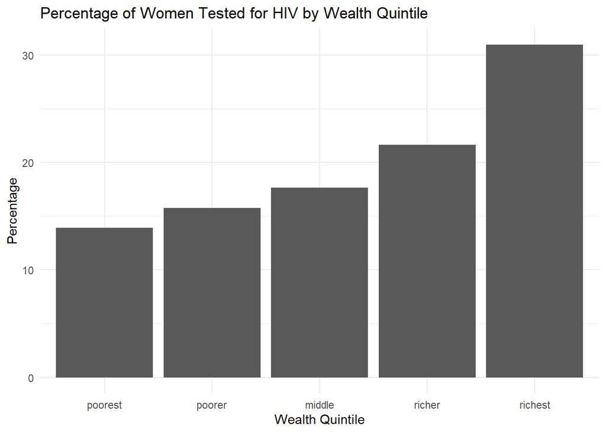

This finding suggests that economic status may play a crucial role in access to HIV-related services. Women in the poorest wealth quintiles may face more barriers—financial, geographic, or informational—to accessing healthcare and testing facilities. Addressing these inequalities is important for improving HIV prevention and early detection among vulnerable populations.